# Module 5 Report

vRoom-vRoom

2022-10-13

## Introduction

A study conducted by Lim, Byrne, and Lee (2008) discusses the importance of thermoregulation in protecting the body from the consequences related to the over heating of the body, claiming that these consequences start arising at 39.5°C and that without thermoregulatoin the body could reach 42.0°C during strenuous exercise. This led us to pose the question does body temperature still vary in human subjects according to activity level?

## Methods

The four participants in this study sat in a chair for five minutes and then had their temperature recorded for 300 seconds. They then did 5 minutes of jumping jacks and immediately got their temperature recorded for another 300 seconds.

The temperature was recorded using a DHT11 sensor connected to an Arduino board. The DHT11 sensor was placed in a small plastic bag and in the participant’s armpit for 5 minutes so that the sensor warmed up to body temperature and the data was then recorded 300 seconds.

## Results

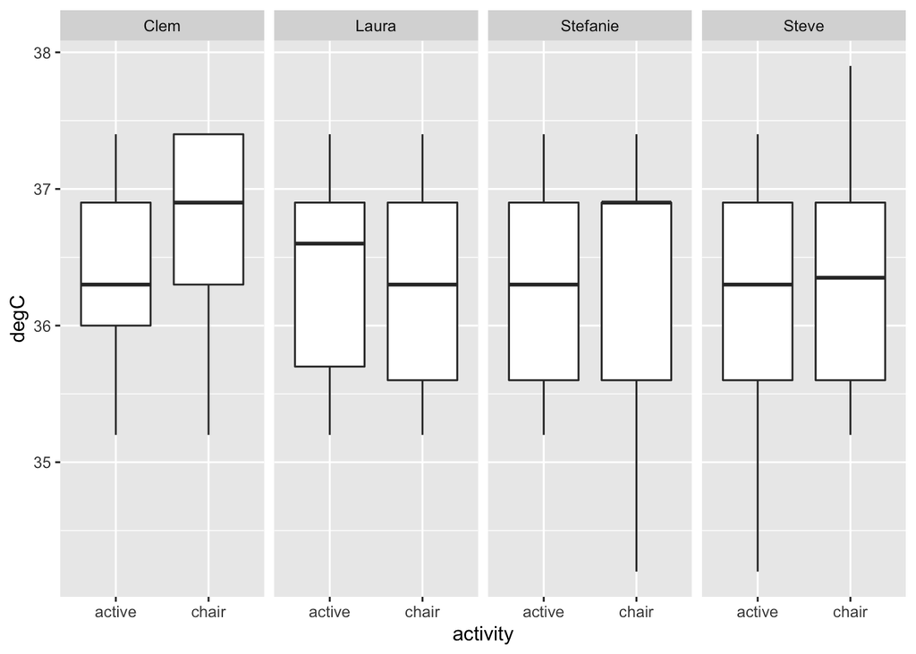

Box plot of temperature range in celcius depending on type of activity for subjects

## Discussion

Our findings display no correlation between temperature variation and activity level. When comparing the overall data for sedentary body temperature to the body temperature data after performing a cardiovascular exercise —jumping jacks— for five minutes, body temperatures tended to be similar. The DHT 11 sensor that was used only recorded temperatures at specific values consistent with each subject, which may be what led to our very consistent data. As our bodies try to maintain homeostasis, we sweat and the evaporation of sweat cools us down. Our bodies’ body temperature regulation to maintain homeostasis works well according to our data as both of our pre-active and post-active body temperatures are similar.

The study conducted by Tanda (2018) shows that body temperature lowers during exercise but immediately returns to the original body temperature at rest as soon as the exercise halted. This agrees with data which showed no change of body temperature before and immediately after exercise.

## Author Contributions

Clem- Helped collect data, and wrote the introduction, methods and references

Stephanie- Wrote the discussion and helped write the methods

Stephen- Operated the data collecting equipment, helped analyze the results

Laura- Looked at previous studies and helped write the results

## References

Lim, Chin Leong, Chris Byrne, and Jason KW Lee. 2008. “Human Thermoregulation and Measurement of Body Temperature in Exercise and Clinical Settings.” *Annals Academy of Medicine Singapore* 37 (4): 347.

Tanda, Giovanni. 2018. “Total Body Skin Temperature of Runners During Treadmill Exercise.” *Journal of Thermal Analysis and Calorimetry* 131 (2): 1967–77.